# A Six-Year Analysis of Methadone and Buprenorphine Prescriptions, and Opioid-Related Hospitalisations in Scotland

B230838

Date last modified: 29 November 2024

## Background

Opioid addiction has become a major public health issue in Scotland, with opioid-related deaths more than doubling between 2011 and 2020<sup>1</sup>. Methadone and buprenorphine are medications used in opioid substitution therapy (OST) to treat opioid addiction<sup>2</sup>. The aims of OST are to reduce or stop opioid use, improve health and social functioning, and help patients avoid the more serious consequences of drug use. Treatment often lasts for several years but can sometimes be required throughout life<sup>3</sup>.

Opioid-related hospitalisation rates serve as a key indicator of the prevalence and severity of opioid addiction in the population. Additionally, the rates of methadone and buprenorphine prescriptions offer insight into the extent to which OST is used in the population to manage opioid addiction. This study analyses data published by Public Health Scotland to examine trends in OST prescription rates and their relationship to opioid-related hospitalisation rates over the financial years 2017/18–2022/23. It also explores regional differences in these trends across Scottish health boards during the same period. The analysis is limited to the 2017/18–2022/23 period due to the availability of data on opioid-related hospitalisations.

## Data Wrangling

### Load Required Packages into the R Session

```r
lapply(c("tidyverse", "here", "janitor", "sf", "gt"), library, character.only = TRUE)
```

### Download Datasets Not Available as URLs

1. Create a “data” folder in your working directory.
2. Download the **Drug-Related Hospital Statistics** dataset: visit the [Drug-Related Hospital Statistics](https://publichealthscotland.scot/publications/drug-related-hospital-statistics/drug-related-hospital-statistics-scotland-2022-to-2023/data-explorer/) page → click the **Data** icon in the **Dashboard** → click the **Download data** icon → save the downloaded file to your “data” folder.
3. Download **Health Board Spatial Data**: visit the [Health Board Spatial Data](https://www.spatialdata.gov.scot/geonetwork/srv/eng/catalog.search#/metadata/f12c3826-4b4b-40e6-bf4f-77b9ed01dc14) page → click the **Download** icon in the **Download** section → save the downloaded folder to your “data” folder.

### Load Datasets

Load the **Drug-Related Hospital Statistics**, **Health Board Geography Codes**, and **Health Board Population Estimates** datasets.

```r
# Vector of dataset filenames or URLs listed in the order above.
dataset_filenames <- c("table_data.csv", "https://www.opendata.nhs.scot/dataset/9f942fdb-e59e-44f5-b534-d6e17229cc7b/resource/652ff726-e676-4a20-abda-435b98dd7bdc/download/hb14_hb19.csv", "https://www.opendata.nhs.scot/dataset/7f010430-6ce1-4813-b25c-f7f335bdc4dc/resource/27a72cc8-d6d8-430c-8b4f-3109a9ceadb1/download/hb2019_pop_est_14102024.csv")

# Vector of desired names for the datasets to be assigned to.
dataset_desired_names <- c("drug_related_hospital_statistics", "hb_names", "hb_population")

# Function to read CSV files either from a URL (if the filename starts with 'https://') or from a local "data" folder, and return a dataframe with cleaned column names.
read_csv_file <- function(filename) {
  dataframe <-
    if (str_detect(filename, "^https://")) {read_csv(filename)}
    else {read_csv(here("data", filename))}
  dataframe %>% clean_names()
  }

dataset_filenames %>%
  # Read each dataset from dataset_filenames using read_csv_file() and return a list of dataframes.
  map(read_csv_file) %>%
  # Assign each dataframe in the list to the global environment with the corresponding name from dataset_desired_names. walk2() iterates over the list of dataframes (.x) and the names from dataset_desired_names (.y).
  walk2(dataset_desired_names, ~ assign(.y, .x, envir = .GlobalEnv))
```

Load **Health Board Spatial Data**.

```r
hb_spatial_data <- st_read(here("data", "SG_NHS_HealthBoards_2019", "SG_NHS_HealthBoards_2019.shp")) %>%
  clean_names() %>%
  # Introduce the 'NHS' prefix in the hb_name column for consistency across dataframes.
  mutate(hb_name = paste0("NHS ", hb_name))
```

Load and combine **Prescriptions in the Community** datasets for all months between financial years 2017/18 and 2022/23, filtering specifically for methadone and buprenorphine prescriptions. The filtering step optimises the computation by narrowing down the dataset before further processing. Note, executing this code will take ~40 mins.

```r
# Vector of URLs read from the text file in the "docs" folder. This file contains URLs that enable download of all 2017/18-2022/23 datasets.
prescription_data_urls <- read_lines(here("docs", "prescriptions_in_the_community_urls.txt"))

# Increase timeout for all operations to 120 seconds to allow large datasets to download (increase further if required).
options(timeout = 120)

# For each URL in prescription_data_urls, read the dataset and filter for methadone and buprenorphine prescriptions. Combine the datasets, by rows, into a single dataframe.
combined_prescription_data <- prescription_data_urls %>%
  map_dfr(~read_csv(.) %>% filter(str_detect(BNFItemDescription, "METHADONE|BUPRENORPHINE"))) %>%
  clean_names()
```

### Process Dataframes

Extract data on opioid-related hospitalisations across NHS health boards for financial years 2017/18-2022/23 from the `drug_related_hospital_statistics` dataframe. The extracted data should include the number of hospital stays related to any opioid-related diagnosis (overdose or mental and behavioural disorder) and in any hospital type (general acute or psychiatric).

```r
opioid_related_hospitalsations <- drug_related_hospital_statistics %>%
  # Filter to reflect the number of opioid-related hospitalisations as defined above.
  filter(measure == "Number", drug_type == "Opioids", diagnosis_grouping == "Any diagnosis", hospital_type == "Any hospital type", activity_type == "Stays", location_type == "NHS Board of residence", financial_year >= "2017/18") %>%
  # Rename columns for clarity and consistency across dataframes.
  rename(number_of_stays = value, hb_name = location) %>%
  # Replace the '&' symbol with 'and' in the hb_name column for consistency across dataframes.
  mutate(hb_name = str_replace(hb_name, " & ", " and "))
```

Extract total population estimates for each health board from `hb_population` for 2017-2022. Since `opioid_related_hospitalsations` is organised by financial year and `hb_population` by calendar year, align the two by assigning each calendar year in `hb_population` to its corresponding financial year using the provided code. This approach offers the most accurate approximation, as a financial year runs from April 6 of one year to April 5 of the next.

```r
hb_population <- hb_population %>%
  # Filter for years '2017' to '2022', where sex is 'All', and excluding entries for the whole of Scotland (health board code: 'S92000003').
  filter(year %in% "2017":"2022", sex == "All", hb != "S92000003") %>%
  # Rename the all_ages column (representing the total population for each health board per year) for clarity.
  rename(hb_pop = all_ages) %>%
  # Create a new column financial_year based on the year column. For each entry, the financial year is the current year followed by the last two digits of the following year.
  mutate(financial_year = paste(year, year + 1 - 2000, sep = "/"))
```

Assign the corresponding financial year to each entry in `combined_prescription_data`. The reason for aligning to financial year, rather than calendar year, in this and the previous code chunk is to ensure that the `combined_prescription_data` can be accurately compared over time with the `opioid_related_hospitalsations` data.

```r
combined_prescription_data <- combined_prescription_data %>%
  mutate(
    # Convert the paid_date_month column from YYYYMM to Date format by appending '01' (to form a YYYYMMDD string) and using as.Date().
    paid_date_month = as.Date(paste0(paid_date_month, "01"), format = "%Y%m%d"),
    # Create a new column financial_year based on the paid_date_month column. For months April (4) to December (12) the financial year is the current year followed by the last two digits of the following year, whereas for January (1) to March (3) the financial year is the previous year followed by the last two digits of the current year.
    financial_year = case_when(month(paid_date_month) >= 4 ~ paste(year(paid_date_month), year(paid_date_month) + 1 - 2000, sep = "/"), TRUE ~ paste(year(paid_date_month) - 1, year(paid_date_month) - 2000, sep = "/"))
    )
```

`combined_prescription_data` for financial years 2017/18-2019/20 has inconsistent column names for health board codes: `hbt` in some months and `hbt2014` in others. This code checks each row to ensure that if one of these columns contains a value, the other is NA. If this condition is satisfied for all rows, values from `hbt` and `hbt2014` are combined into a new column `hb`. This enables joining with other dataframes based on health board code.

```r
all_good <- combined_prescription_data %>%
  # For each row, return TRUE if one of the columns hbt or hbt2014 is non-NA and the other is NA, otherwise return FALSE. Store the result in the new condition column.
  mutate(condition = if_else((!is.na(hbt) & is.na(hbt2014)) | (is.na(hbt) & !is.na(hbt2014)), TRUE, FALSE)) %>%
  # Confirm all values in the condition column are TRUE. all() returns TRUE if this is the case.
  summarise(check_condition = all(condition))

# Execute the code below only if all_good is TRUE.
if (all_good == TRUE) {
    combined_prescription_data <- combined_prescription_data %>%
      # Create a new column hb that takes values from hbt, or from hbt2014 if hbt is NA.
      mutate(hb = coalesce(hbt, hbt2014))
    }
```

### Join Dataframes

Create a function that performs a left join between two dataframes (i.e., it keeps all rows from the left dataframe and only matching rows from the right dataframe).

```r
# Left join function. Arguments taken are: the left dataframe, the right dataframe, the column to join by, and the columns from the right dataframe to include in the result.
left_joining_function <- function(left_dataframe, right_dataframe, join_column, columns_from_right) {
  left_dataframe %>% left_join(select(right_dataframe, all_of(c(columns_from_right, join_column))), by = join_column)
}
```

Join `hb_population` and `combined_prescription_data` with `hb_names` to assign health board names to each entry in the former dataframes. This enables easier joining downstream, as health board codes are inconsistent over time due to some being archived and new ones introduced.

```r
# List of dataframes to be joined.
dataframe_names <- list(hb_population, combined_prescription_data)

# Apply left_joining_function() to each dataframe in dataframe_names with hb_names and return a list of joined dataframes.
population_and_prescription_joins <- map(dataframe_names, ~ left_joining_function(..1, hb_names, "hb", "hb_name"))

# Reassign the results of the joins to their respective variables.
hb_population <- population_and_prescription_joins[[1]]
combined_prescription_data <- population_and_prescription_joins[[2]]
```

Join `combined_prescription_data` with `hb_population`, `hb_spatial_data`, and `opioid_related_hospitalsations`, keeping only relevant columns.

```r
# Tibble containing the arguments for each join, where each row defines the parameters for one join.
joining_arguments <- tibble(
  right_dataframe = list(hb_population, hb_spatial_data, opioid_related_hospitalsations),
  join_column = list(c("hb_name", "financial_year"), "hb_name", c("hb_name", "financial_year")),
  columns_from_right = list("hb_pop", "geometry", "number_of_stays")
  )

# Sequentially apply left_joining_function() to join combined_prescription_data with each dataframe in joining_arguments.
for (i in seq(nrow(joining_arguments))) {
  combined_prescription_data <- left_joining_function(combined_prescription_data, joining_arguments$right_dataframe[[i]], joining_arguments$join_column[[i]], joining_arguments$columns_from_right[[i]])
  }

# Rename the the final result of the joins.
joined_data <- combined_prescription_data
```

### Calculate Statistics

Calculate the total number of methadone and buprenorphine prescriptions per year and health board from `joined_data`. Assign this dataframe to `master_data`, which will serve as the foundation for generating three distinct summary dataframes, each of which will be used to create individual visualisations.

```r
master_data <- joined_data %>%
  group_by(financial_year, hb_name) %>%
  summarise(
    # Within each group (year and health board), sum number_of_paid_items for rows where 'bnf_item_description' contains 'METHADONE' or 'BUPRENORPHINE'.
    methadone_prescriptions = sum(number_of_paid_items[str_detect(bnf_item_description, "METHADONE")]),
    buprenorphine_prescriptions = sum(number_of_paid_items[str_detect(bnf_item_description, "BUPRENORPHINE")]),
    # Retain the specified non-aggregated columns in the summarise() output by taking the first value for each group - this is possible as their values do not vary within groups.
    across(c(geometry, number_of_stays, hb_pop), first)
    )
```

Calculate the annual rates of opioid-related hospitalisations and prescriptions (methadone, buprenorphine or both) per 1000 people across the whole of Scotland. Pivot this dataframe to a long format to make it easier to use in ggplot visualisations.

```r
scotland_prescriptions_hospitalisations <- master_data %>%
  group_by(financial_year) %>%
  summarise(
    # For each group (year), sum the specified columns, divide by the sum of hb_pop (ie: total Scottish population), and multiply by 1000.
    across(c(methadone_prescriptions, buprenorphine_prescriptions, number_of_stays), ~ sum(.x) / sum(hb_pop) * 1000, .names = "{.col}_per_1000"),
    # Sum the combined methadone_prescriptions and buprenorphine_prescriptions, then apply the same computation as above to the total.
    methadone_buprenorphine_per_1000 = sum(methadone_prescriptions + buprenorphine_prescriptions) / sum(hb_pop) * 1000
    ) %>%
    # Reshape dataframe to a long format where the values for the specified columns are gathered into the new column rate, and their names gathered into the new column statistic.
  pivot_longer(values_to = "rate", cols = c(methadone_buprenorphine_per_1000, methadone_prescriptions_per_1000, buprenorphine_prescriptions_per_1000, number_of_stays_per_1000), names_to = "statistic")
```

Calculate the annual combined rate of methadone and buprenorphine prescriptions per 1000 people across Scottish health boards. Total these rates for each health board over the financial years 2017/18-2022/23, and order the dataframe columns left to right based on these values in descending order.

```r
hb_combined_prescriptions <- master_data %>%
  group_by(financial_year, hb_name) %>%
  # For each group (year and health board), sum the specified columns, divide by hb_pop, and multiply by 1000.
  summarise(methadone_buprenorphine_per_1000 = sum(methadone_prescriptions + buprenorphine_prescriptions) / hb_pop * 1000) %>%
  # Remove the 'NHS' prefix from the hb_name column and replace 'and' with  '&' for clarity.
  mutate(hb_name = str_replace_all(hb_name, c("^NHS " = "", " and " = " & "))) %>%
  # Reshape dataframe to a wide format where methadone_buprenorphine_per_year values are separated into different columns based on health board.
  pivot_wider(names_from = hb_name, values_from = methadone_buprenorphine_per_1000) %>%
  # Remove the grouping applied before summarisation to ensure bind_rows() operates over the entire dataframe.
  ungroup() %>%
  # Create new row 'All Years' by summing each column across all financial_years.
  bind_rows(summarise(., across(-financial_year, sum)) %>% mutate(financial_year = "All Years"))

# Extract the 'All Years' row -> Exclude financial_year column -> Convert row values into a vector -> Sort values in decreasing order -> Retrieve column names after sorting.
ordered_column_names <- hb_combined_prescriptions %>% filter(financial_year == "All Years") %>% select(-financial_year) %>% unlist() %>% sort(decreasing = TRUE) %>% names()

# Reorder columns in hb_combined_prescriptions based on ordered_column_names.
hb_combined_prescriptions <- hb_combined_prescriptions %>%
  select(financial_year, all_of(ordered_column_names))
```

Calculate the annual rate of opioid-related hospitalisations per 1000 people across Scottish health boards. Compute the correlation coefficients between these rates and time (2017/18-2022/23) for each health board. Return a spatial dataframe with the geometry of each health board.

```r
hb_hospitalisations <- master_data %>%
  group_by(financial_year, hb_name) %>%
  summarise(
    # For each group (year and health board), sum the number_of_stays column, divide by hb_pop, and multiply by 1000.
    number_of_stays_per_1000 = sum(number_of_stays) / hb_pop * 1000,
    # Retain the non-aggregated geometry column in the summarise() output by taking the first value for each group.
    geometry = first(geometry)
    )

correlation_coefficients <- hb_hospitalisations %>%
  group_by(hb_name) %>%
  # For each group (health board), calculate Pearson correlation coefficients between the financial year (converted to a numeric factor) and number_of_stays_per_1000.
  summarise(correlation = cor(as.numeric(as.factor(financial_year)), number_of_stays_per_1000))

hb_hospitalisations_correlation <- correlation_coefficients %>%
  # Join correlation_coefficients with hb_hospitalisations by hb_name, and retain the geometry column.
  left_joining_function(hb_hospitalisations, "hb_name", "geometry") %>%
  # Remove duplicate rows based on the combination of the specified columns.
  distinct(hb_name, correlation, geometry) %>%
  # Convert to sf object to ensure geometry is recognised.
  st_as_sf() %>%
  # Transform the coordinate reference system to WGS84 (latitudes and longitudes).
  st_transform(crs = 4326)
```

## Data Visualisation and Discussion

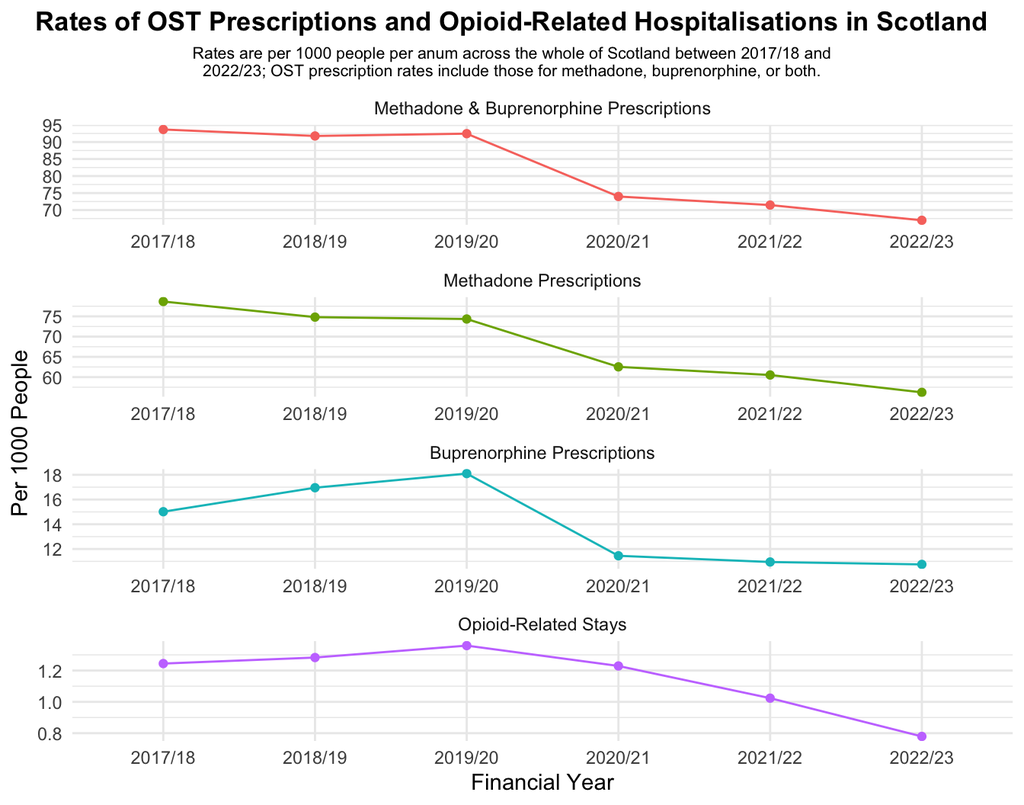

```r
# Vector of custom facet labels.
facet_labels <- c(
  "methadone_buprenorphine_per_1000" = "Methadone & Buprenorphine Prescriptions",
  "methadone_prescriptions_per_1000" = "Methadone Prescriptions",
  "buprenorphine_prescriptions_per_1000" = "Buprenorphine Prescriptions",
  "number_of_stays_per_1000" = "Opioid-Related Stays"
)

scotland_prescriptions_hospitalisations %>%
  # Reorder the statistic columns factor levels to control the order of facets in the plot.
  mutate(statistic = factor(statistic, levels = c("methadone_buprenorphine_per_1000", "methadone_prescriptions_per_1000", "buprenorphine_prescriptions_per_1000", "number_of_stays_per_1000"))) %>%
  ggplot(aes(x = financial_year, y = rate, group = statistic, color = statistic)) +
  # Plot a line graph and remove the legend.
  geom_line(show.legend = FALSE) +
  # Add points to the line graph and remove the legend.
  geom_point(show.legend = FALSE) +
  # Facet the plot by the statistic column, allow scaled y-axes for each facet, apply custom facet labels, position facet labels at the top of each facet, and arrange all facets in 1 column.
  facet_wrap(statistic ~., scales = "free", labeller = labeller(statistic = facet_labels), strip.position = "top", ncol = 1) +
  # Add title, subtitle, and axes labels.
  labs(title = "Rates of OST Prescriptions and Opioid-Related Hospitalisations in Scotland", subtitle = "Rates are per 1000 people per anum across the whole of Scotland between 2017/18 and\n2022/23; OST prescription rates include those for methadone, buprenorphine, or both.", y = "Per 1000 People", x = "Financial Year") +
  theme_minimal() +
  # Position the title at the top of the plot area, and format both the title and subtitle, centering them.
  theme(plot.title.position = "plot", plot.title = element_text(size = 13, face = "bold", hjust = 0.5), plot.subtitle = element_text(size = 8, hjust = 0.5))
```

The largest drop in OST prescription rates occurred between 2019/2020 and 2020/21, coinciding with the start of the COVID-19 pandemic. This decline was likely due to a reduction in prescription frequency, a result of a new medication strategy focused on prescribing larger take-home supplies of OST medication to reduce social contact<sup>4</sup>. Even after social contact restrictions were eased in 2021/2022, prescription rates did not return to pre-pandemic levels, suggesting the new medication strategy persisted.

The change in medication strategy introduced inconsistencies in prescription rates over the time period studied, making it difficult to interpret their relationship with opioid-related hospitalisation rates. However, it appeared that prior to the change, declining overall prescription rates coincided with rising hospitalisation rates, while afterwards, both rates appeared to decline together. This disparity suggests that multiple factors, not accounted for in this study, likely influence both the rates of OST prescriptions and opioid-related hospitalisations.

Prescription rates for methadone appeared to decline consistently throughout the analysed time period. This likely reflects changes in the OST treatments offered by NHS health boards in Scotland, with an increasing preference for buprenorphine-based medications over methadone due to the latter’s higher toxicity and greater potential for abuse<sup>4</sup>.

```r
hb_combined_prescriptions %>%
  gt() %>%
  # Colour cells in the table based on column values using a gradient from yellow (low) to red (high), automatically scaled to the data range. Apply to all columns except financial_year.
  data_color(columns = -financial_year, fn = scales::col_numeric(palette = c("yellow", "red"), domain = NULL),
    # Do not apply colour to 'All Years' row.
    rows = financial_year != "All Years"
  ) %>%
  # Format numerical values to have 0 decimal places.
  fmt_number(., decimals = 0) %>%
  # Centre text in all columns but financial_year.
  cols_align(align = "center", columns = -financial_year) %>%
  # Add spanner across all columns except financial_year.
  tab_spanner("NHS health boards", columns = -financial_year) %>%
  # Rename column for clarity.
  cols_label(financial_year = "Financial Year") %>%
  # Add title and subtitle labels.
  tab_header(title = md("**Trends in Combined Methadone and Buprenorphine Prescription Rates Across Scottish NHS Health Boards (2017/18–2022/23)**"), subtitle = "Rates are per 1000 people per anum.") %>%
  # Format the title, subtitle, and text within the table.
  tab_options(table.font.size = "10px", heading.title.font.size = "17px", heading.subtitle.font.size = "11px")
```

**Trends in Combined Methadone and Buprenorphine Prescription Rates Across Scottish NHS Health Boards (2017/18–2022/23)**

Rates are per 1000 people per anum.

| Financial Year | NHS health boards Greater Glasgow & Clyde | NHS health boards Lothian | NHS health boards Dumfries & Galloway | NHS health boards Ayrshire & Arran | NHS health boards Lanarkshire | NHS health boards Grampian | NHS health boards Shetland | NHS health boards Tayside | NHS health boards Fife | NHS health boards Forth Valley | NHS health boards Borders | NHS health boards Highland | NHS health boards Orkney | NHS health boards Western Isles |
| --- | --- | --- | --- | --- | --- | --- | --- | --- | --- | --- | --- | --- | --- | --- |
| 2017/18 | 150 | 93 | 107 | 97 | 81 | 87 | 60 | 71 | 57 | 68 | 48 | 52 | 13 | 10 |
| 2018/19 | 140 | 96 | 107 | 92 | 87 | 83 | 65 | 59 | 57 | 73 | 59 | 51 | 31 | 11 |
| 2019/20 | 138 | 100 | 111 | 91 | 85 | 82 | 69 | 65 | 63 | 69 | 65 | 51 | 28 | 9 |
| 2020/21 | 94 | 95 | 73 | 86 | 61 | 59 | 67 | 66 | 67 | 44 | 52 | 46 | 27 | 9 |
| 2021/22 | 90 | 90 | 70 | 84 | 62 | 57 | 70 | 67 | 67 | 46 | 49 | 36 | 25 | 12 |
| 2022/23 | 83 | 84 | 58 | 76 | 59 | 58 | 68 | 63 | 62 | 47 | 46 | 34 | 33 | 11 |
| All Years | 693 | 556 | 527 | 527 | 435 | 425 | 399 | 390 | 374 | 347 | 319 | 269 | 157 | 62 |

*Cells in warmer colours (shades of red) represent higher prescription rates, while those in cooler colours (shades of yellow) represent lower rates. Colouring is scaled to each health board’s data range and is not comparable across columns. Health boards are ordered left to right by total prescription rates over all years in descending order.*

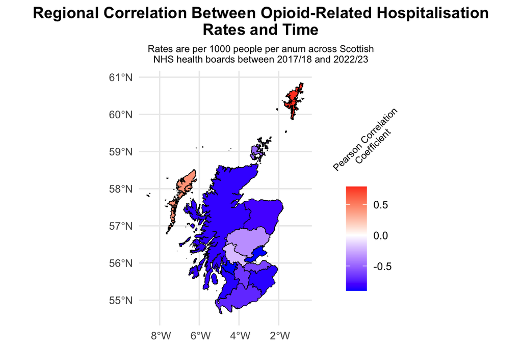

```r
hb_hospitalisations_correlation %>%
  ggplot(aes(fill = correlation)) +
  # Plot spatial features (multipolygons from geometry column) with black borders.
  geom_sf(color = "black", size = 0.3) +
  # Set fill (correlation variable) colour gradient from blue (negative) to red (positive) and white (0).
  scale_fill_gradient2(low = "blue", mid = "white", high = "red", midpoint = 0) +
  # Add title, subtitle, and fill legend labels.
  labs(title = "Regional Correlation Between Opioid-Related Hospitalisation\nRates and Time", subtitle = "Rates are per 1000 people per anum across Scottish\nNHS health boards between 2017/18 and 2022/23", fill = "Pearson Correlation\nCoefficient") +
  theme_minimal() +
  # As above, with the fill legend title rotated 45 degrees and centered.
  theme(plot.title.position = "plot", plot.title = element_text(size = 13, face = "bold", hjust = 0.5), plot.subtitle = element_text(size = 8, hjust = 0.5), legend.title = element_text(size = 8, angle = 45, hjust = 0.5))
```

*Red fill indicates positive correlations (ie: increases in hospitalisation rates over time), while blue fill indicates negative correlations (ie: decreases in hospitalisation rates over time).*

The map further reveals that health boards with declining prescription rates also tended to have decreasing hospitalisation rates over the same period. For example, NHS Greater Glasgow and Clyde demonstrated a decline in prescription rates and the strongest negative correlation between hospitalisation rates and time. In contrast, health boards with rising prescription rates often saw little change in hospitalisation rates or, in some cases, increases, such as in NHS Shetland and NHS Western Isles. However, these correlation coefficients should be interpreted cautiously as in many health boards they are based on small numbers.

## Limitations and Future Perspectives

A significant limitation of this study is that it only considered the number of methadone and buprenorphine prescriptions, and did not account for the dosage or quantity of the prescribed medication. Including these variables in the analysis would have provided a more precise measure of the extent to which OST was used in the population to manage opioid addiction. Additionally, it would have enabled investigation of how the dosage and quantity of OST prescriptions changed after the shift in medication strategy during the COVID-19 pandemic.

Future studies that explore the relationship between OST prescription rates and opioid-related hospitalisation rates over time should also consider other influencing factors, such as improvements in other opioid addiction treatments and social deprivation. Additionally, studies examining regional trends in Scotland should focus on more granular data, such as information at the Health and Social Care Partnership (HSCP) level.

Finally, when interpreting the results, readers should keep in mind that: methadone and buprenorphine are sometimes prescribed for chronic pain, boundary changes to four health boards between February 2018 and April 2019 may affect year-on-year comparability, and data from NHS Tayside is missing for October 2018 in the **Prescriptions in the Community** dataset.

## Acknolwedgements

I used OpenAI’s ChatGPT to enhance my understanding of the code from the workshops, to help write complex functions, to custom format the HTML output document, and to troubleshoot errors encountered during coding.

## References

1. Markoulidakis, Andreas, et al. (2024). Prevalence of Opioid Dependence in Scotland 2015–2020: A Multi‐Parameter Estimation of Prevalence (MPEP) Study. Addiction. doi:https://doi.org/10.1111/add.16500.
2. Department of Health (2017). Drug Misuse and Dependence UK Guidelines on Clinical Management. [online] available at: https://assets.publishing.service.gov.uk/government/uploads/system/uploads/attachment_data/file/673978/clinical_guidelines_2017.pdf.
3. World Health Organization (2009). Guidelines for the psychosocially assisted pharmacological treatment of opioid dependence. [online] available at: https://www.who.int/publications/i/item/9789241547543.
4. The Scottish Government (2022). Opioid Substitution Therapy (OST) Implicated Deaths and Prescribing: Evidence Review. [online] available at: https://www.gov.scot/publications/evidence-review-opioid-substitution-therapy-ost-implicated-deaths-prescribing-scotland/documents/.